# bi594_HW1

# <sub>############################</sub>

##### Assign Taxonomy

# <sub>############################</sub>

# we downlaoded the fungal data from the UNITE online fungal database at: https://unite.ut.ee/repository.php#general.

# We selected the most recent database but used the smaller of the two version because we could not get the larger on to upload through R for the analysis.

```r
taxa <- assignTaxonomy(seqtab.nochim, "/Users/christiangagnon/Documents/BI594/sh_general_release_dynamic_02.02.2019.fasta",multithread = TRUE, tryRC=TRUE)
```

```
## UNITE fungal taxonomic reference detected.
```

```r
unname(head(taxa))
```

```
##      [,1]       [,2]               [,3]                [,4] [,5] [,6] [,7]
## [1,] "k__Fungi" "p__Basidiomycota" NA                  NA   NA   NA   NA
## [2,] "k__Fungi" "p__Basidiomycota" NA                  NA   NA   NA   NA
## [3,] "k__Fungi" "p__Basidiomycota" NA                  NA   NA   NA   NA
## [4,] "k__Fungi" "p__Basidiomycota" NA                  NA   NA   NA   NA
## [5,] "k__Fungi" "p__Basidiomycota" "c__Agaricomycetes" NA   NA   NA   NA
## [6,] "k__Fungi" "p__Basidiomycota" NA                  NA   NA   NA   NA
```

```r
taxa.print <- taxa  # Removing sequence rownames for display only
rownames(taxa.print) <- NULL
head(taxa.print)
```

```
##      Kingdom    Phylum             Class               Order Family Genus
## [1,] "k__Fungi" "p__Basidiomycota" NA                  NA    NA     NA
## [2,] "k__Fungi" "p__Basidiomycota" NA                  NA    NA     NA
## [3,] "k__Fungi" "p__Basidiomycota" NA                  NA    NA     NA
## [4,] "k__Fungi" "p__Basidiomycota" NA                  NA    NA     NA
## [5,] "k__Fungi" "p__Basidiomycota" "c__Agaricomycetes" NA    NA     NA
## [6,] "k__Fungi" "p__Basidiomycota" NA                  NA    NA     NA
##      Species
## [1,] NA
## [2,] NA
## [3,] NA
## [4,] NA
## [5,] NA
## [6,] NA
```

```r
#to come back to later
#saveRDS(seqtab.nochim, file="/Users/christiangagnon/Documents/BI594/mrits_seqtab.nochim.rds")
#saveRDS(taxa, file="~/Desktop/mrits/mrits_taxa.rds")

#write.csv(seqtab.nochim, file="~/Desktop/mrits/mrits_seqtab.nochim.csv")
#write.csv(taxa, file="~/Desktop/mrits/mrits_taxa.csv")

#If you need to read in previously saved datafiles
#seqtab.nochim <- readRDS("mrits_seqtab.nochim.rds")
#taxa <- readRDS("mrits_taxa.rds")
```

# <sub>############################</sub>

##### handoff 2 phyloseq

# <sub>############################</sub>

```r
#BiocManager::install("phyloseq")
BiocManager::install("Rmisc")
```

```r
library('phyloseq')
library('ggplot2')
library('Rmisc')
#import dataframe holding sample information
samdf<-read.csv("/Users/christiangagnon/Documents/BI594/mrits_sampledata.csv")
head(samdf)
```

```
##   Sample            Site X.DNA...ng.ul. island direction in_off site
## 1    101 Moorea NW Inner            304 Moorea        NW  Inner  MNW
## 2    113 Moorea NW Outer            379 Moorea        NW  Outer  MNW
## 3    115 Moorea NW Outer            407 Moorea        NW  Outer  MNW
## 4    116 Moorea NW Outer            670 Moorea        NW  Outer  MNW
## 5    117 Moorea NW Outer            755 Moorea        NW  Outer  MNW
## 6    130 Moorea NW Outer            200 Moorea        NW  Outer  MNW
##   site_zone DNAcon zoox
## 1      MNWI  304.2    y
## 2      MNWO  379.0    y
## 3      MNWO  407.0    y
## 4      MNWO  670.0    y
## 5      MNWO  755.0    y
## 6      MNWO  200.0    y
```

```r
rownames(samdf) <- samdf$Sample

# Construct phyloseq object (straightforward from dada2 outputs)
ps <- phyloseq(otu_table(seqtab.nochim, taxa_are_rows=FALSE),
               sample_data(samdf),
               tax_table(taxa))

ps
```

```
## phyloseq-class experiment-level object
## otu_table()   OTU Table:         [ 84 taxa and 81 samples ]
## sample_data() Sample Data:       [ 81 samples by 10 sample variables ]
## tax_table()   Taxonomy Table:    [ 84 taxa by 7 taxonomic ranks ]
```

# Visualize alpha-diversity - *Should be done on raw, untrimmed dataset*

# total species diversity in a landscape (gamma diversity) is determined by two different things, the mean species diversity in sites or habitats at a more local scale (alpha diversity) and the differentiation among those habitats (beta diversity)

# Shannon:Shannon entropy quantifies the uncertainty (entropy or degree of surprise) associated with correctly predicting which letter will be the next in a diverse string. Based on the weighted geometric mean of the proportional abundances of the types, and equals the logarithm of true diversity. When all types in the dataset of interest are equally common, the Shannon index hence takes the value ln(actual # of types). The more unequal the abundances of the types, the smaller the corresponding Shannon entropy. If practically all abundance is concentrated to one type, and the other types are very rare (even if there are many of them), Shannon entropy approaches zero. When there is only one type in the dataset, Shannon entropy exactly equals zero (there is no uncertainty in predicting the type of the next randomly chosen entity).

# Simpson:equals the probability that two entities taken at random from the dataset of interest represent the same type. equal to the weighted arithmetic mean of the proportional abundances pi of the types of interest, with the proportional abundances themselves being used as the weights. Since mean proportional abundance of the types increases with decreasing number of types and increasing abundance of the most abundant type, λ obtains small values in datasets of high diversity and large values in datasets of low diversity. This is counterintuitive behavior for a diversity index, so often such transformations of λ that increase with increasing diversity have been used instead. The most popular of such indices have been the inverse Simpson index (1/λ) and the Gini–Simpson index (1 − λ).

# Only statistically significant difference was found between zone (in vs offshore); not between sites

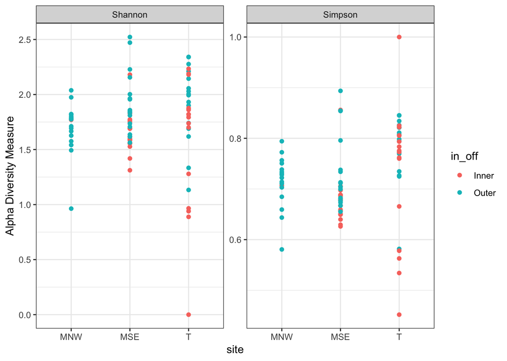

```r
plot_richness(ps, x="site", measures=c("Shannon", "Simpson"), color="in_off") + theme_bw()
```

```r
df <- data.frame(estimate_richness(ps, split=TRUE, measures =c("Shannon","InvSimpson","Chao1")),sample_data(ps)$site,sample_data(ps)$in_off,sample_data(ps)$Sample,sample_data(ps)$site_zone)
df
```

```
##      Chao1  se.chao1   Shannon InvSimpson sample_data.ps..site
## X101    17 0.4850713 1.7700913   3.411163                  MNW
## X113    12 0.0000000 1.6664918   3.367992                  MNW
## X115    12 0.0000000 1.7113401   3.702021                  MNW
## X116    11 0.0000000 1.7886811   4.859532                  MNW
## X117     6 0.0000000 1.4933092   3.678404                  MNW
## X130    26 0.0000000 2.0381111   4.009397                  MNW
## X157     9 0.0000000 1.5412761   3.169982                  MNW
## X158    15 0.0000000 1.7747489   3.821384                  MNW
## X159    17 0.0000000 1.8006007   3.455883                  MNW
## X172    20 0.0000000 1.6936656   2.805235                  MNW
## X173    12 0.0000000 1.5756604   2.934963                  MNW
## X174    10 0.0000000 1.6269403   3.599384                  MNW
## X175    20 0.0000000 1.9745744   4.106393                  MNW
## X177    14 0.0000000 1.8224793   4.394783                  MNW
## X178     3 0.0000000 0.9634142   2.384287                  MNW
## X179    16 0.0000000 1.7824697   3.497431                  MNW
## X180    17 0.4850713 1.8174247   3.752464                  MNW
## X276    11 0.0000000 1.5993121   3.182002                  MSE
## X297    14 0.0000000 1.5562674   2.698064                  MSE
## X300    17 0.0000000 1.6937602   2.862047                  MSE
## X301    16 0.0000000 1.7500240   3.304396                  MSE
## X303    15 0.0000000 2.1804840   6.943246                  MSE
## X304    19 0.0000000 1.8293417   3.392534                  MSE
## X305    12 0.0000000 1.5875994   3.107274                  MSE
## X307    10 0.0000000 1.4191989   2.674166                  MSE
## X308    16 0.0000000 1.6178701   2.775929                  MSE
## X310    16 0.0000000 1.6894119   2.912955                  MSE
## X311     7 0.0000000 1.3118618   2.850920                  MSE
## X315    11 0.0000000 1.5860236   3.208946                  MSE
## X316    18 0.0000000 1.7731978   3.004830                  MSE
## X351    10 0.0000000 1.5568266   3.107167                  MSE
## X377    16 0.0000000 1.7635235   3.206427                  MSE
## X378    10 0.0000000 1.5271904   2.933613                  MSE
## X380     0       NaN 0.0000000        Inf                    T
## X384    25 0.0000000 2.3409575   6.458928                    T
## X386    16 0.0000000 2.0562655   5.593758                    T
## X389    10 0.0000000 1.6187126   4.339462                    T
## X394    12 0.0000000 1.6902210   3.655222                    T
## X397    20 0.0000000 2.1439578   4.956920                    T
```

[output cut: 191 more lines]

```
## X604                      MSEO
## X607                      MSEO
## X608                      MSEO
## X609                      MSEO
## X612                      MSEO
## X614                      MSEO
## X616                      MSEO
## X617                      MSEO
## X618                      MSEO
## X619                      MSEO
## X626                      MSEO
## X627                      MSEO
## X630                      MSEO
## X632                      MSEO
## X633                      MSEO
```

```r
df$site <- df$sample_data.ps..site
df$name <- df$sample_data.ps..Sample
df$zone <- df$sample_data.ps..in_off
df$site_zone <- df$sample_data.ps..site_zone

#write.csv(df,file="~/Desktop/mrits/mrits_diversity.csv")
#df <- read.csv("~/Desktop/mrits/mrits_diversity.csv")

diver <- summarySE(df,measurevar="Shannon",groupvars=c("site","zone"), na.rm=T)
diver
```

```
##   site  zone  N  Shannon        sd         se        ci
## 1  MNW Inner  1 1.770091        NA         NA       NaN
## 2  MNW Outer 16 1.691949 0.2422669 0.06056673 0.1290949
## 3  MSE Inner 16 1.652618 0.1943793 0.04859482 0.1035774
## 4  MSE Outer 16 1.931834 0.2867620 0.07169050 0.1528047
## 5    T Inner 16 1.572096 0.6032845 0.15082112 0.3214676
## 6    T Outer 16 1.921532 0.3462280 0.08655700 0.1844919
```

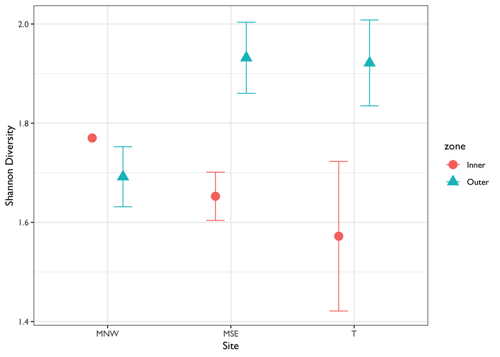

```r
pd=position_dodge(.5)
quartz()
ggplot(diver, aes(x=site, y=Shannon,group=zone,color=zone,fill=zone,shape=zone))+
  geom_errorbar(aes(ymin=Shannon-se,ymax=Shannon+se),position=pd,lwd=0.4,width=0.3)+
  geom_point(aes(colour=zone, shape=zone),size=4,position=pd)+
  xlab("Site")+
  ylab("Shannon Diversity")+
  theme_bw()+
  theme(text=element_text(family="Gill Sans MT"))
```

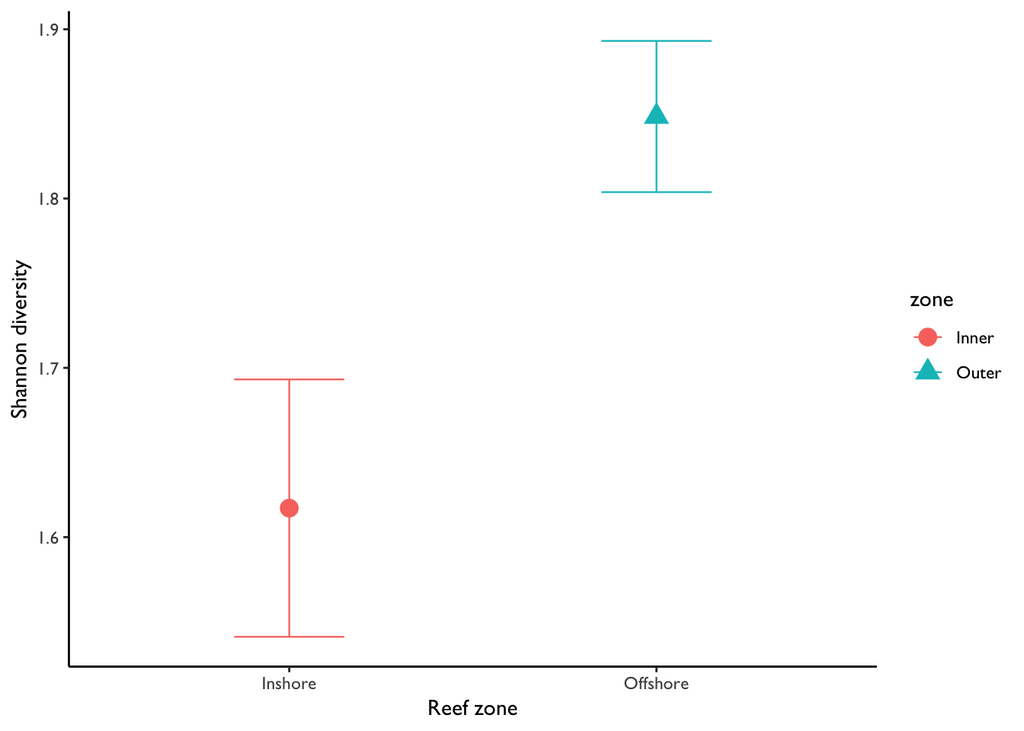

```r
shzone <- summarySE(df,measurevar="Shannon",groupvars=c("zone"), na.rm=T)
pd=position_dodge(.5)
quartz()
ggplot(shzone, aes(x=zone, y=Shannon,group=zone,color=zone,fill=zone,shape=zone))+
  geom_errorbar(aes(ymin=Shannon-se,ymax=Shannon+se),position=pd,lwd=0.4,width=0.3)+
  geom_point(aes(colour=zone, shape=zone),size=4,position=pd)+
  xlab("Reef zone")+
  ylab("Shannon diversity")+
  theme_classic()+
  theme(text=element_text(family="Gill Sans MT"))+
  scale_x_discrete(labels=c("Inshore","Offshore"))
```

```r
df
```

```
##      Chao1  se.chao1   Shannon InvSimpson sample_data.ps..site
## X101    17 0.4850713 1.7700913   3.411163                  MNW
## X113    12 0.0000000 1.6664918   3.367992                  MNW
## X115    12 0.0000000 1.7113401   3.702021                  MNW
## X116    11 0.0000000 1.7886811   4.859532                  MNW
## X117     6 0.0000000 1.4933092   3.678404                  MNW
## X130    26 0.0000000 2.0381111   4.009397                  MNW
## X157     9 0.0000000 1.5412761   3.169982                  MNW
## X158    15 0.0000000 1.7747489   3.821384                  MNW
## X159    17 0.0000000 1.8006007   3.455883                  MNW
## X172    20 0.0000000 1.6936656   2.805235                  MNW
## X173    12 0.0000000 1.5756604   2.934963                  MNW
## X174    10 0.0000000 1.6269403   3.599384                  MNW
## X175    20 0.0000000 1.9745744   4.106393                  MNW
## X177    14 0.0000000 1.8224793   4.394783                  MNW
## X178     3 0.0000000 0.9634142   2.384287                  MNW
## X179    16 0.0000000 1.7824697   3.497431                  MNW
## X180    17 0.4850713 1.8174247   3.752464                  MNW
## X276    11 0.0000000 1.5993121   3.182002                  MSE
## X297    14 0.0000000 1.5562674   2.698064                  MSE
## X300    17 0.0000000 1.6937602   2.862047                  MSE
## X301    16 0.0000000 1.7500240   3.304396                  MSE
## X303    15 0.0000000 2.1804840   6.943246                  MSE
## X304    19 0.0000000 1.8293417   3.392534                  MSE
## X305    12 0.0000000 1.5875994   3.107274                  MSE
## X307    10 0.0000000 1.4191989   2.674166                  MSE
## X308    16 0.0000000 1.6178701   2.775929                  MSE
## X310    16 0.0000000 1.6894119   2.912955                  MSE
## X311     7 0.0000000 1.3118618   2.850920                  MSE
## X315    11 0.0000000 1.5860236   3.208946                  MSE
## X316    18 0.0000000 1.7731978   3.004830                  MSE
## X351    10 0.0000000 1.5568266   3.107167                  MSE
## X377    16 0.0000000 1.7635235   3.206427                  MSE
## X378    10 0.0000000 1.5271904   2.933613                  MSE
## X380     0       NaN 0.0000000        Inf                    T
## X384    25 0.0000000 2.3409575   6.458928                    T
## X386    16 0.0000000 2.0562655   5.593758                    T
## X389    10 0.0000000 1.6187126   4.339462                    T
## X394    12 0.0000000 1.6902210   3.655222                    T
## X397    20 0.0000000 2.1439578   4.956920                    T
```

[output cut: 191 more lines]

```
## X604                      MSEO  MSE  604 Outer      MSEO
## X607                      MSEO  MSE  607 Outer      MSEO
## X608                      MSEO  MSE  608 Outer      MSEO
## X609                      MSEO  MSE  609 Outer      MSEO
## X612                      MSEO  MSE  612 Outer      MSEO
## X614                      MSEO  MSE  614 Outer      MSEO
## X616                      MSEO  MSE  616 Outer      MSEO
## X617                      MSEO  MSE  617 Outer      MSEO
## X618                      MSEO  MSE  618 Outer      MSEO
## X619                      MSEO  MSE  619 Outer      MSEO
## X626                      MSEO  MSE  626 Outer      MSEO
## X627                      MSEO  MSE  627 Outer      MSEO
## X630                      MSEO  MSE  630 Outer      MSEO
## X632                      MSEO  MSE  632 Outer      MSEO
## X633                      MSEO  MSE  633 Outer      MSEO
```

```r
avod <- aov(Shannon~site*zone,data=df)
summary(avod)
```

```
##             Df Sum Sq Mean Sq F value  Pr(>F)
## site         2  0.105  0.0523   0.394 0.67546
## zone         1  1.450  1.4496  10.940 0.00145 **
## site:zone    2  0.157  0.0783   0.591 0.55630
## Residuals   75  9.938  0.1325
## ---
## Signif. codes:  0 '***' 0.001 '**' 0.01 '*' 0.05 '.' 0.1 ' ' 1
```

```r
# Df Sum Sq Mean Sq F value   Pr(>F)
# site         2  1.045  0.5225   3.396   0.0379 *
#   zone         1  2.892  2.8922  18.797 3.78e-05 ***
#   site:zone    2  0.011  0.0053   0.034   0.9663
# Residuals   90 13.848  0.1539
# ---
#   Signif. codes:  0 ‘***’ 0.001 ‘**’ 0.01 ‘*’ 0.05 ‘.’ 0.1 ‘ ’ 1

diver2 <- summarySE(df,measurevar="InvSimpson",groupvars=c("site","zone"), na.rm=T)
diver2
```

```
##   site  zone  N InvSimpson       sd        se        ci
## 1  MNW Inner  1   3.411163       NA        NA       NaN
## 2  MNW Outer 16   3.596221 0.608421 0.1521053 0.3242047
## 3  MSE Inner 16   3.260282 1.005159 0.2512898 0.5356115
## 4  MSE Outer 16   4.224568 1.870457 0.4676141 0.9966959
## 5    T Inner 16        Inf      NaN       NaN       NaN
## 6    T Outer 16   4.898664 1.136587 0.2841468 0.6056445
```

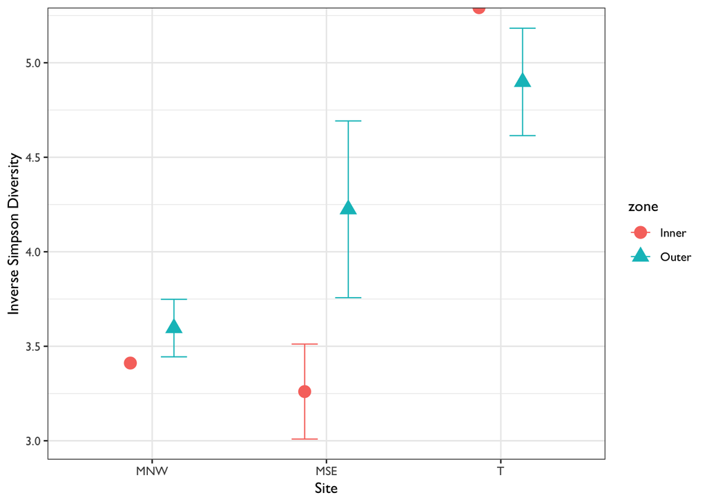

```r
quartz()
ggplot(diver2, aes(x=site, y=InvSimpson,group=zone,color=zone,fill=zone,shape=zone)) +
  geom_errorbar(aes(ymin=InvSimpson-se,ymax=InvSimpson+se),position=pd,lwd=0.4,width=0.3)+
  geom_point(aes(colour=zone, shape=zone),size=4,position=pd)+
  xlab("Site")+
  ylab("Inverse Simpson Diversity")+
  theme_bw()+
  theme(text=element_text(family="Gill Sans MT"))
```

```r
diver3 <- summarySE(df,measurevar="Chao1",groupvars=c("site","zone"), na.rm=T)
diver3
```

```
##   site  zone  N   Chao1       sd       se       ci
## 1  MNW Inner  1 17.0000       NA       NA      NaN
## 2  MNW Outer 16 13.7500 5.686241 1.421560 3.029984
## 3  MSE Inner 16 13.6250 3.500000 0.875000 1.865018
## 4  MSE Outer 16 20.6250 6.344289 1.586072 3.380633
## 5    T Inner 16 13.1875 8.400149 2.100037 4.476123
## 6    T Outer 16 15.7500 6.465292 1.616323 3.445111
```

[figure not shown]

```r
ggplot(diver3, aes(x=site, y=Chao1)) +
  geom_errorbar(aes(ymin=Chao1-se,ymax=Chao1+se),lwd=0.4,width=0.3)+
  geom_point(aes(colour = factor(zone), shape=factor(zone)),size=4) +
  xlab("Site")+
  ylab("Inverse Simpson Diversity")+
  theme_bw()#+
```

```r
#scale_colour_manual(values=colorz)
```